# MATH 3080 Lab Project 8

Harrison Webb

03/30/2022

# Problem 1 (Verzani problem 12.28)

*In the data set `mtcars` the variables `mpg`, `cyl`, and `am` indicate the miles per gallon, the number of cylinders, and the type of transmission, respectively. Perform a two-way ANOVA modeling `mpg` by the `cyl` and `am`, each treated as a categorical variable.*

*Is there an indication of an interaction? Do both the number of cylinders and the type of transmission make a difference?*

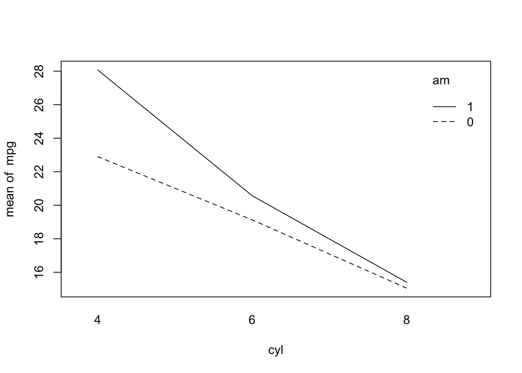

```r
with(mtcars, interaction.plot(cyl, am, mpg))
```

The interaction plot is not completely parallel, suggesting that an interaction may be happening, but there is no intersection, which would strongly suggest an interaction.

```r
model1 <- lm(mpg ~ as.factor(cyl) * as.factor(am), data = mtcars)
summary(model1)
```

```
##
## Call:
## lm(formula = mpg ~ as.factor(cyl) * as.factor(am), data = mtcars)
##
## Residuals:
##     Min      1Q  Median      3Q     Max
## -6.6750 -1.1000  0.1125  1.6875  5.8250
##
## Coefficients:
##                                Estimate Std. Error t value Pr(>|t|)
## (Intercept)                      22.900      1.751  13.081 6.06e-13 ***
## as.factor(cyl)6                  -3.775      2.316  -1.630 0.115155
## as.factor(cyl)8                  -7.850      1.957  -4.011 0.000455 ***
## as.factor(am)1                    5.175      2.053   2.521 0.018176 *
## as.factor(cyl)6:as.factor(am)1   -3.733      3.095  -1.206 0.238553
## as.factor(cyl)8:as.factor(am)1   -4.825      3.095  -1.559 0.131069
## ---
## Signif. codes:  0 '***' 0.001 '**' 0.01 '*' 0.05 '.' 0.1 ' ' 1
##
## Residual standard error: 3.032 on 26 degrees of freedom
## Multiple R-squared:  0.7877, Adjusted R-squared:  0.7469
## F-statistic: 19.29 on 5 and 26 DF,  p-value: 5.179e-08
```

The F-statistic p-value here is extremely small, so we can say with near-certainty that at least one treatment has an effect on the response variable (mpg). We see that the treatments with a statistically significant effect are having 8 cylinders (negative relationship with mpg) and having an automatic transmission (positive relationship with mpg).